# 3rd_week

```python
import pandas as pd
import numpy as np
import matplotlib.pyplot as plt
import statsmodels.api as sm
import warnings
%pylab inline
```

```python
data = pd.read_csv('trips_by_regions.csv')
```

```python
data.head()
```

|  | region | west | east | south | north | 2016-05-01(hour: 0) | 2016-05-01(hour: 1) | 2016-05-01(hour: 2) | 2016-05-01(hour: 3) | 2016-05-01(hour: 4) | ... | 2016-05-31(hour: 14) | 2016-05-31(hour: 15) | 2016-05-31(hour: 16) | 2016-05-31(hour: 17) | 2016-05-31(hour: 18) | 2016-05-31(hour: 19) | 2016-05-31(hour: 20) | 2016-05-31(hour: 21) | 2016-05-31(hour: 22) | 2016-05-31(hour: 23) |
| --- | --- | --- | --- | --- | --- | --- | --- | --- | --- | --- | --- | --- | --- | --- | --- | --- | --- | --- | --- | --- | --- |
| 0 | 1 | -74.25559 | -74.244478 | 40.496120 | 40.504508 | 0.0 | 0.0 | 0.0 | 0.0 | 0.0 | ... | 0.0 | 0.0 | 0.0 | 0.0 | 0.0 | 0.0 | 0.0 | 0.0 | 0.0 | 0.0 |
| 1 | 2 | -74.25559 | -74.244478 | 40.504508 | 40.512896 | 0.0 | 0.0 | 0.0 | 0.0 | 0.0 | ... | 0.0 | 0.0 | 0.0 | 0.0 | 0.0 | 0.0 | 0.0 | 0.0 | 0.0 | 0.0 |
| 2 | 3 | -74.25559 | -74.244478 | 40.512896 | 40.521285 | 0.0 | 0.0 | 0.0 | 0.0 | 0.0 | ... | 0.0 | 0.0 | 0.0 | 0.0 | 0.0 | 0.0 | 0.0 | 0.0 | 0.0 | 0.0 |
| 3 | 4 | -74.25559 | -74.244478 | 40.521285 | 40.529673 | 0.0 | 0.0 | 0.0 | 0.0 | 0.0 | ... | 0.0 | 0.0 | 0.0 | 0.0 | 0.0 | 0.0 | 0.0 | 0.0 | 0.0 | 0.0 |
| 4 | 5 | -74.25559 | -74.244478 | 40.529673 | 40.538061 | 0.0 | 0.0 | 0.0 | 0.0 | 0.0 | ... | 0.0 | 0.0 | 0.0 | 0.0 | 0.0 | 0.0 | 0.0 | 0.0 | 0.0 | 0.0 |

5 rows × 749 columns

```python
# let's use a cell with Empire State Building
EMB_lon = 40.748460
EMB_lat = -73.985779
EMB_region = data[(data['west'] <= EMB_lat) & (EMB_lat <= data['east'])
                             & (data['south'] <= EMB_lon) & (EMB_lon <= data['north'])]
```

```python
EMB_region.drop(['region', 'west', 'east', 'south', 'north'], axis=1, inplace=True)
EMB_region = np.transpose(EMB_region)
EMB_region.rename(columns={1230: 'value'}, inplace=True)
EMB_region = EMB_region.set_index(pd.date_range('05/1/2016', periods=int(24*31), freq='H'))
```

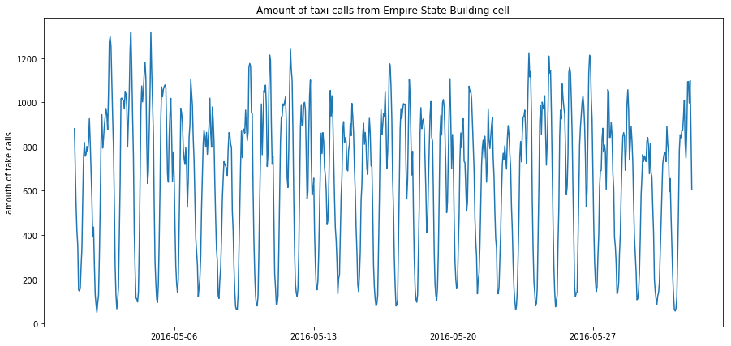

```python
plt.figure(figsize(15,7))
plt.plot(EMB_region.value)
plt.ylabel('amouth of take calls')
plt.title('Amount of taxi calls from Empire State Building cell')
plt.show()
```

## Regression features

```python
isWeekend = lambda x: 1 if x in (5, 6) else 0
EMB_region['is_weekend'] = [isWeekend(i) for i in EMB_region.index.dayofweek]
```

```python
EMB_region['roll_value_12'] = EMB_region['value'].rolling(12).mean()
EMB_region['roll_value_24'] = EMB_region['value'].rolling(24).mean()

EMB_region['roll_value_48'] = EMB_region['value'].rolling(48).mean()
EMB_region['roll_value_168'] = EMB_region['value'].rolling(168).mean()

EMB_region['sin_value_6'] = np.sin(2*np.pi * EMB_region.index.hour/6)
EMB_region['cos_value_6'] = np.cos(2*np.pi * EMB_region.index.hour/6)

EMB_region['sin_value_12'] = np.sin(2*np.pi * EMB_region.index.hour/12)
EMB_region['cos_value_12'] = np.cos(2*np.pi * EMB_region.index.hour/12)

EMB_region['sin_value_16'] = np.sin(2*np.pi * EMB_region.index.hour/16)
EMB_region['cos_value_16'] = np.cos(2*np.pi * EMB_region.index.hour/16)

EMB_region['sin_value_24'] = np.sin(2*np.pi * EMB_region.index.hour/24)
EMB_region['cos_value_24'] = np.cos(2*np.pi * EMB_region.index.hour/24)

EMB_region['sin_value_48'] = np.sin(2*np.pi * EMB_region.index.hour/48)
EMB_region['cos_value_48'] = np.cos(2*np.pi * EMB_region.index.hour/48)

EMB_region['sin_value_96'] = np.sin(2*np.pi * EMB_region.index.hour/96)
EMB_region['cos_value_96'] = np.cos(2*np.pi * EMB_region.index.hour/96)

EMB_region['sin_value_168'] = np.sin(2*np.pi * EMB_region.index.hour/168)
EMB_region['cos_value_168'] = np.cos(2*np.pi * EMB_region.index.hour/168)
```

```python
from sklearn.linear_model import LinearRegression, Lasso, Ridge
regressor = LinearRegression()
lasso = Lasso()
ridge = Ridge()
regressor.fit(EMB_region.drop(['value'], axis=1).fillna(0), EMB_region['value'])
lasso.fit(EMB_region.drop(['value'], axis=1).fillna(0), EMB_region['value'])
ridge.fit(EMB_region.drop(['value'], axis=1).fillna(0), EMB_region['value'])
```

```
Ridge(alpha=1.0, copy_X=True, fit_intercept=True, max_iter=None,
   normalize=False, random_state=None, solver='auto', tol=0.001)
```

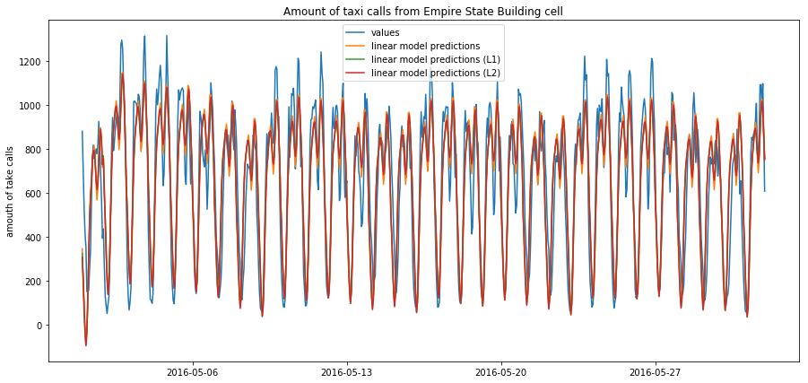

```python
plt.figure(figsize(15,7))
plt.plot(EMB_region.value, label='values')
plt.plot(EMB_region.index, regressor.predict(EMB_region.drop(['value'], axis=1).fillna(0)),
         label='linear model predictions')
plt.plot(EMB_region.index, lasso.predict(EMB_region.drop(['value'], axis=1).fillna(0)),
         label='linear model predictions (L1)')
plt.plot(EMB_region.index, ridge.predict(EMB_region.drop(['value'], axis=1).fillna(0)),
         label='linear model predictions (L2)')
plt.ylabel('amouth of take calls')
plt.title('Amount of taxi calls from Empire State Building cell')
plt.legend()
plt.show()
```

As we can see from the plot, all linear models predict pretty much the same

Let's look at remains plot

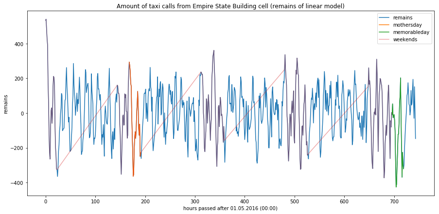

```python
EMB_region['predictions'] = regressor.predict(EMB_region.drop(['value'], axis=1).fillna(0))
EMB_region['remains'] = EMB_region['value'] - EMB_region['predictions']
indecis = list(range(len(EMB_region.value)))[:]
indecis_weekends = list(i for i in indecis if EMB_region['is_weekend'].values[i])
indecis_mothersday = list(i for i in indecis if EMB_region.index.day[i]==8)
indecis_memorableday = list(i for i in indecis if EMB_region.index.day[i]==30)
plt.plot(indecis, EMB_region.remains[indecis], label='remains')
plt.plot(indecis_mothersday, EMB_region.remains[indecis_mothersday], label='mothersday')
plt.plot(indecis_memorableday, EMB_region.remains[indecis_memorableday], label='memorableday')
plt.plot(indecis_weekends, EMB_region.remains[indecis_weekends], label='weekends', alpha=0.4)
plt.xlabel('hours passed after 01.05.2016 (00:00)')
plt.ylabel('remains')
plt.title('Amount of taxi calls from Empire State Building cell (remains of linear model)')
plt.legend()
plt.show()
```

We can see all official USA holidays (Mother's day (08.05.2016) and Memorable day (30.05.2016))

Memorable day is Monday and it's lower than its mean, so let's count it in our model too

```python
EMB_region['is_memorable_day'] = [(lambda x: 1 if x==30 else 0)(x) for x in EMB_region.index.day]
```

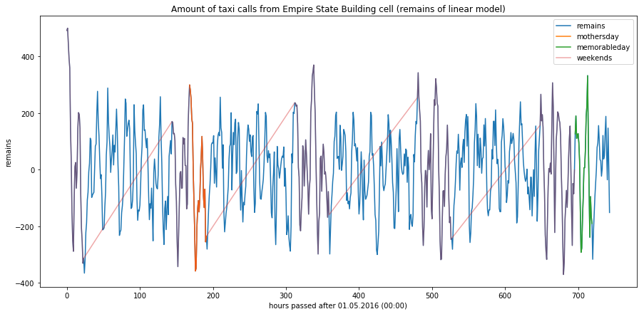

```python
regressor = LinearRegression()
regressor.fit(EMB_region.drop(['value', 'predictions', 'remains'], axis=1).fillna(0), EMB_region['value'])
EMB_region['predictions'] = regressor.predict(EMB_region.drop(['value', 'predictions', 'remains'], axis=1).fillna(0))
EMB_region['remains'] = EMB_region['value'] - EMB_region['predictions']
indecis = list(range(len(EMB_region.value)))[:]
indecis_weekends = list(i for i in indecis if EMB_region['is_weekend'].values[i])
indecis_mothersday = list(i for i in indecis if EMB_region.index.day[i]==8)
indecis_memorableday = list(i for i in indecis if EMB_region.index.day[i]==30)
plt.plot(indecis, EMB_region.remains[indecis], label='remains')
plt.plot(indecis_mothersday, EMB_region.remains[indecis_mothersday], label='mothersday')
plt.plot(indecis_memorableday, EMB_region.remains[indecis_memorableday], label='memorableday')
plt.plot(indecis_weekends, EMB_region.remains[indecis_weekends], label='weekends', alpha=0.4)
plt.xlabel('hours passed after 01.05.2016 (00:00)')
plt.ylabel('remains')
plt.title('Amount of taxi calls from Empire State Building cell (remains of linear model)')
plt.legend()
plt.show()
```

Now we can see that Memorable day looks like a normal Monday. Mother's day still looks like a normal Sunday

## SARIMAX model setting

H0: time series is not static

H1: H0 is incorrect

```
Dickey - Fuller criteria: p-value = 9.86937760053072e-16
```

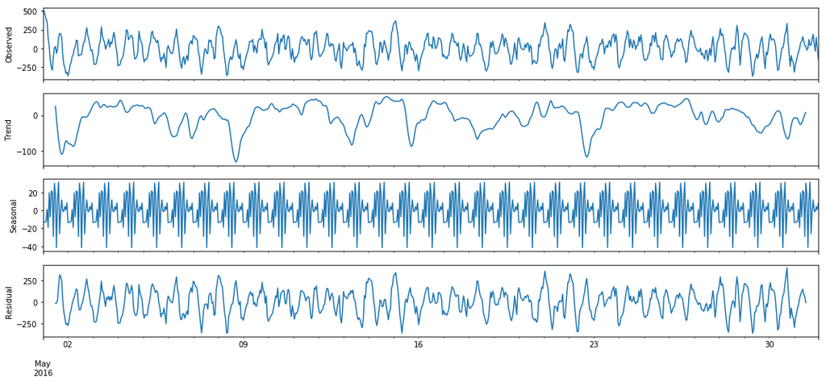

```python
print("Dickey - Fuller criteria: p-value = {}".format(sm.tsa.stattools.adfuller(EMB_region.remains)[1]))
sm.tsa.seasonal_decompose(EMB_region.remains).plot()
plt.show()
```

We can see that Dicky-Fuller criteria is pretty low, but there are some issues on STL-decomposition (it may be because of anomalies in our data like incounted holidays etc). Let's try to make the time series smoother

```python
EMB_region['remains_24'] = EMB_region['remains'] - EMB_region['remains'].shift(24)
```

```
Dickey - Fuller criteria: p-value = 1.1923987462653546e-11
```

[figure not shown]

```python
print("Dickey - Fuller criteria: p-value = {}".format(sm.tsa.stattools.adfuller(EMB_region.remains_24[24:])[1]))
sm.tsa.seasonal_decompose(EMB_region.remains_1[24:]).plot()
plt.show()
```

STL-decomposition looks well. We can try to choose parameters for ARIMA model

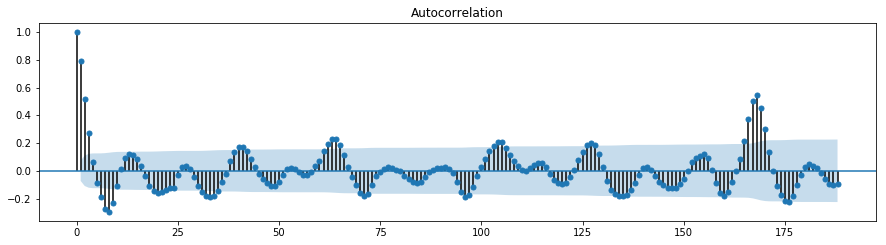

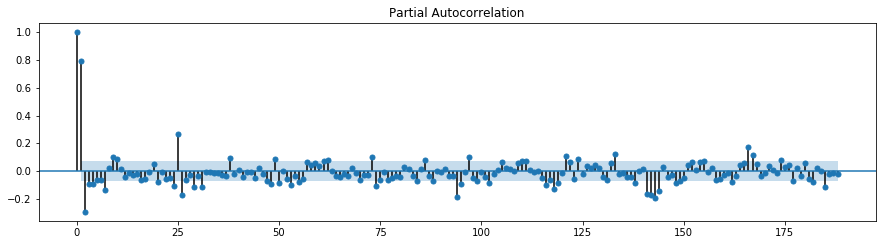

```python
plt.figure(figsize(15,8))
ax = plt.subplot(211)
sm.graphics.tsa.plot_acf(EMB_region.remains_24.dropna().squeeze(), lags=188, ax=ax)
pylab.show()
ax = plt.subplot(212)
sm.graphics.tsa.plot_pacf(EMB_region.remains_24.dropna().squeeze(), lags=188, ax=ax)
pylab.show()
```

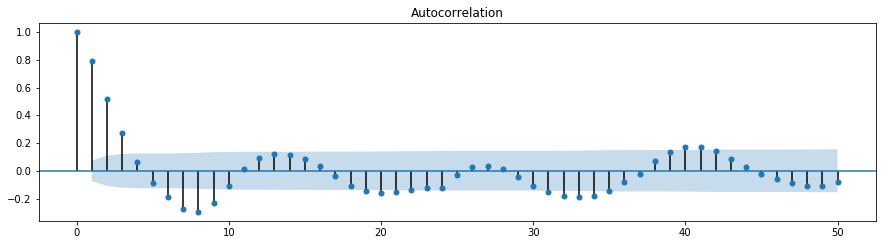

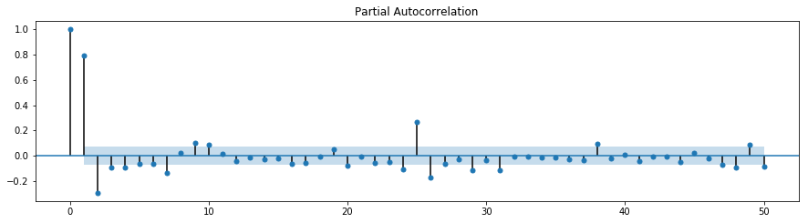

```python
plt.figure(figsize(15,8))
ax = plt.subplot(211)
sm.graphics.tsa.plot_acf(EMB_region.remains_24.dropna().squeeze(), lags=50, ax=ax)
pylab.show()
ax = plt.subplot(212)
sm.graphics.tsa.plot_pacf(EMB_region.remains_24.dropna().squeeze(), lags=50, ax=ax)
pylab.show()
```

Amount of different ARIMA models is ambigious if we take Q and (or) P = 7. Let's values of 1 season (because of a large time of fitting)

Q = 1; q = 10; P = 1; p = 7

```python
from itertools import product
D = 1
d = 1
ps = range(0, 8)
qs = range(0, 11)
Ps = range(0, 2)
Qs = range(0, 2)
parameters_list = list(product(ps, qs, Ps, Qs))
print('amount of different models: {}'.format(len(parameters_list)))
```

```
amount of different models: 352
```

```python
%%time
results = []
best_aic = float("inf")
warnings.filterwarnings('ignore')

for i, param in enumerate(parameters_list):
    try:
        model = sm.tsa.statespace.SARIMAX(EMB_region.value,
                                          exog=EMB_region[['is_weekend', 'roll_value_12',
                                                            'roll_value_24', 'roll_value_48',
                                                            'roll_value_168',
                                                            'sin_value_6', 'cos_value_6',
                                                            'sin_value_12', 'cos_value_12',
                                                            'sin_value_16', 'cos_value_16',
                                                            'sin_value_24', 'cos_value_24',
                                                            'sin_value_48', 'cos_value_48',
                                                            'sin_value_96', 'cos_value_96',
                                                            'sin_value_168', 'cos_value_168',
                                                            'is_memorable_day']].fillna(0),
                                          order=(param[0], d, param[1]),
                                        seasonal_order=(param[2], D, param[3], 24)).fit(disp=-1)
    except ValueError:
        continue
    aic = model.aic
    if aic < best_aic:
        best_model = model
        best_aic = aic
        best_param = param
    results.append([param, model.aic])
    print('{} out of {} '.format(i, len(parameters_list)))

warnings.filterwarnings('default')
```

[output not shown]

[output cut: 214 more lines]

```python
result_table = pd.DataFrame(results)
result_table.columns = ['parameters', 'aic']
print(result_table.sort_values(by = 'aic', ascending=True).head())
```

```
       parameters          aic
67   (2, 7, 1, 1)  8362.713843
219  (7, 5, 1, 1)  8365.734286
123  (4, 6, 1, 1)  8366.369248
195  (6, 7, 1, 1)  8367.465301
127  (4, 7, 1, 1)  8370.097675
```

## Best model:

```python
print(best_model.summary())
```

```
                                 Statespace Model Results
==========================================================================================
Dep. Variable:                              value   No. Observations:                  744
Model:             SARIMAX(2, 1, 7)x(1, 1, 1, 24)   Log Likelihood               -4149.357
Date:                            Fri, 05 Oct 2018   AIC                           8362.714
Time:                                    08:06:00   BIC                           8509.205
Sample:                                05-01-2016   HQIC                          8419.271
                                     - 05-31-2016
Covariance Type:                              opg
====================================================================================
                       coef    std err          z      P>|z|      [0.025      0.975]
------------------------------------------------------------------------------------
is_weekend         -25.0378     16.548     -1.513      0.130     -57.471       7.395
roll_value_12        0.2722      0.094      2.896      0.004       0.088       0.456
roll_value_24        0.1965      0.161      1.220      0.222      -0.119       0.512
roll_value_48       -0.0435      0.125     -0.348      0.728      -0.288       0.201
roll_value_168      -0.0615      0.073     -0.838      0.402      -0.205       0.082
sin_value_6          0.0041   4301.365   9.57e-07      1.000   -8430.516    8430.524
cos_value_6         -0.0015   3575.792  -4.14e-07      1.000   -7008.424    7008.421
sin_value_12        -0.0026   1.34e+04  -1.96e-07      1.000   -2.62e+04    2.62e+04
cos_value_12         0.0020   1.23e+04   1.65e-07      1.000   -2.42e+04    2.42e+04
sin_value_16        -0.0020   1.14e+04  -1.77e-07      1.000   -2.23e+04    2.23e+04
cos_value_16        -0.0031   1.18e+04  -2.61e-07      1.000   -2.31e+04    2.31e+04
sin_value_24         0.0021   1.17e+04   1.79e-07      1.000   -2.29e+04    2.29e+04
cos_value_24        -0.0008   1.27e+04  -6.12e-08      1.000    -2.5e+04     2.5e+04
sin_value_48        -0.0005   1.05e+04  -4.83e-08      1.000   -2.06e+04    2.06e+04
cos_value_48         0.0009   4850.915   1.84e-07      1.000   -9507.619    9507.620
sin_value_96        -0.0009   8647.311  -1.06e-07      1.000   -1.69e+04    1.69e+04
cos_value_96        -0.0003   3688.203  -8.84e-08      1.000   -7228.746    7228.745
sin_value_168       -0.0006   7227.665  -8.66e-08      1.000   -1.42e+04    1.42e+04
cos_value_168       -0.0008   4305.517  -1.77e-07      1.000   -8438.659    8438.657
is_memorable_day   -22.1929     62.636     -0.354      0.723    -144.957     100.571
ar.L1                1.7653      0.004    459.670      0.000       1.758       1.773
ar.L2               -0.9983      0.004   -256.916      0.000      -1.006      -0.991
ma.L1               -1.7497      3.825     -0.457      0.647      -9.247       5.748
ma.L2                0.7467      2.869      0.260      0.795      -4.876       6.370
ma.L3                0.1266      0.080      1.591      0.112      -0.029       0.282
ma.L4                0.0412      0.476      0.087      0.931      -0.891       0.974
ma.L5               -0.0669      0.643     -0.104      0.917      -1.327       1.193
ma.L6                0.1035      0.377      0.274      0.784      -0.636       0.843
ma.L7               -0.2013      0.776     -0.260      0.795      -1.722       1.319
ar.S.L24             0.1909      0.046      4.108      0.000       0.100       0.282
ma.S.L24            -0.8904      0.034    -26.485      0.000      -0.956      -0.825
sigma2            5700.2458   2.18e+04      0.262      0.794    -3.7e+04    4.84e+04
===================================================================================
Ljung-Box (Q):                       60.44   Jarque-Bera (JB):                16.49
Prob(Q):                              0.02   Prob(JB):                         0.00
Heteroskedasticity (H):               0.71   Skew:                            -0.03
Prob(H) (two-sided):                  0.01   Kurtosis:                         3.74
===================================================================================

Warnings:
[1] Covariance matrix calculated using the outer product of gradients (complex-step).
[2] Covariance matrix is singular or near-singular, with condition number 2.74e+17. Standard errors may be unstable.
```

```
Dickey - Fuller test: p=9.495553825144432e-14
```

[figure not shown]

```python
plt.figure(figsize(15,8))
plt.subplot(211)
best_model.resid[24:].plot()
plt.ylabel('Residuals')

ax = plt.subplot(212)
sm.graphics.tsa.plot_acf(best_model.resid[24:].values.squeeze(), lags=170, ax=ax)

print("Dickey - Fuller test: p={}".format(sm.tsa.stattools.adfuller(best_model.resid[24:])[1]))
```

Residuals and autocorrelation graphs look fine (only random noise), but there are anomalysis in a week seasoning (probably because of incorrect Q, P in our model's setting)

[figure not shown]

```python
EMB_region['model'] = best_model.fittedvalues
plt.figure(figsize(15,7))
EMB_region['value'].plot()
EMB_region.model[24:].plot(color='r')
plt.ylabel('Amount of taxi calls')
pylab.show()
```

## Predictions in scale

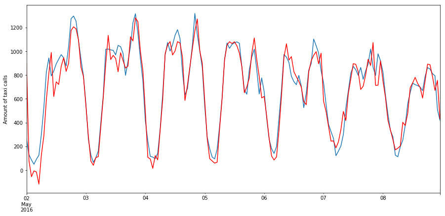

```python
EMB_region['model'] = best_model.fittedvalues
plt.figure(figsize(15,7))
EMB_region['value'][24:192].plot()
EMB_region.model[24:192].plot(color='r')
plt.ylabel('Amount of taxi calls')
pylab.show()
```

## 1 week predictions

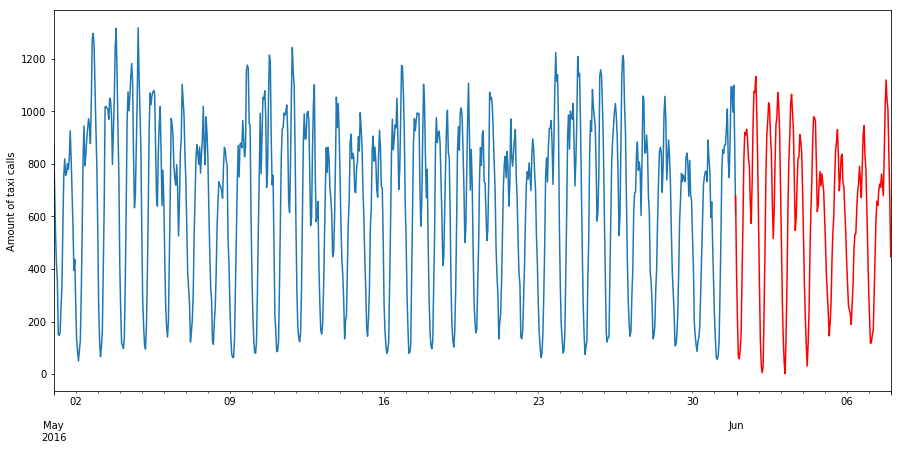

```python
EMB_region['model'] = best_model.fittedvalues
plt.figure(figsize(15,7))
EMB_region['value'].plot()
best_model.predict(start=EMB_region.shape[0] - 1,
                    end=(EMB_region.shape[0] + 168),
                    exog=EMB_region[['is_weekend', 'roll_value_12',
                                    'roll_value_24', 'roll_value_48',
                                    'roll_value_168',
                                    'sin_value_6', 'cos_value_6',
                                    'sin_value_12', 'cos_value_12',
                                    'sin_value_16', 'cos_value_16',
                                    'sin_value_24', 'cos_value_24',
                                    'sin_value_48', 'cos_value_48',
                                    'sin_value_96', 'cos_value_96',
                                    'sin_value_168', 'cos_value_168',
                                    'is_memorable_day']].fillna(0)[-169:]).plot(color='r')
plt.ylabel('Amount of taxi calls')
pylab.show()
```

Generally, model predicts well. It counts week seasons and some anomalysis (because of the regression features). But the prediction's lowest values are lower than the mean of the time series. The difference is not very big, but it can be a further problem. Maybe it can be because we've taken not real amount of (Q, P) in our SARIMA model